# Prediksi faktor risiko Rekurensi Ameloblastoma

2023-02-19

```r
library(caret)
library(tidyverse)
library(rpart)
library(rattle)
library(ipred)
library(plyr)
library(e1071)
library(randomForest)
library(readxl)
library(dplyr)
library(wesanderson)
```

# Data Preparasi

## Mengubah Jenis Data

Di sini akan dilakukan preparasi/*cleaning* data, pertama dengan mengganti numerik ke kategorik

```r
dataku<-dataku[-1]
dataku$JK <- ifelse(dataku$JK == 0, "Laki-laki", "Perempuan")
dataku$JK <- factor(dataku$JK, levels = c("Laki-laki", "Perempuan"))
levels(dataku$JK)
```

```
## [1] "Laki-laki" "Perempuan"
```

```r
dataku$Lokasi <- ifelse(dataku$Lokasi == 0, "Multilokular", "Unilokular")
dataku$Lokasi <- factor(dataku$Lokasi, levels = c("Multilokular", "Unilokular"))
levels(dataku$Lokasi)
```

```
## [1] "Multilokular" "Unilokular"
```

```r
dataku$Perluasan <- ifelse(dataku$Perluasan == 0, "Stage_2", "Stage_1")
dataku$Perluasan <- factor(dataku$Perluasan, levels = c("Stage_2", "Stage_1"))
levels(dataku$Perluasan)
```

```
## [1] "Stage_2" "Stage_1"
```

```r
dataku$Radiografis <- ifelse(dataku$Radiografis == 0, "Multilokular", "Unilokular")
dataku$Radiografis <- factor(dataku$Lokasi, levels = c("Multilokular", "Unilokular"))
levels(dataku$Radiografis)
```

```
## [1] "Multilokular" "Unilokular"
```

```r
dataku$Histopatologis <- ifelse(dataku$Histopatologis == 0, "Folikular",
                                ifelse(dataku$Histopatologis == 1, "Pleksiform",
                                       ifelse(dataku$Histopatologis == 2, "Akantomatosa",
                                              ifelse(dataku$Histopatologis == 3, "Desmoplastik",
                                                     ifelse(dataku$Histopatologis == 4, "Campuran",
                                                            "Unikistik")))))
dataku$Histopatologis <- factor(dataku$Histopatologis, levels = c("Folikular", "Pleksiform", "Akantomatosa", "Desmoplastik", "Campuran",
                                                                  "Unikistik"))
levels(dataku$Histopatologis)
```

```
## [1] "Folikular"    "Pleksiform"   "Akantomatosa" "Desmoplastik" "Campuran"
## [6] "Unikistik"
```

```r
dataku$Modalitasperawatan <- ifelse(dataku$Modalitasperawatan == 0, "Konservatif", "Radikal")
dataku$Modalitasperawatan <- factor(dataku$Modalitasperawatan, levels = c("Konservatif", "Radikal"))
levels(dataku$Modalitasperawatan)
```

```
## [1] "Konservatif" "Radikal"
```

```r
dataku$Rekurensi <- ifelse(dataku$Rekurensi == 0, "Rekuren", "Tidak_Rekuren")
dataku$Rekurensi <- factor(dataku$Rekurensi, levels = c("Rekuren", "Tidak_Rekuren"))
levels(dataku$Rekurensi)
```

```
## [1] "Rekuren"       "Tidak_Rekuren"
```

```r
dataku$Usia <- ifelse(dataku$Usia == 0, "<=20tahun", ifelse(dataku$Usia == 1, "21-40tahun", "41-60tahun"))
dataku$Usia <- factor(dataku$Usia, levels = c("<=20tahun", "21-40tahun", "41-60tahun"))
levels(dataku$Usia)
```

```
## [1] "<=20tahun"  "21-40tahun" "41-60tahun"
```

## Mengecek Data

```r
# melihat 6 data pertama
DT::datatable(head(dataku,20))
```

|  | JK | Usia | Lokasi | Perluasan | Radiografis | Histopatologis | Modalitasperawatan | Rekurensi |
| --- | --- | --- | --- | --- | --- | --- | --- | --- |
| 1 | Perempuan | 41-60tahun | Multilokular | Stage_1 | Multilokular | Campuran | Konservatif | Rekuren |
| 2 | Perempuan | 21-40tahun | Multilokular | Stage_1 | Multilokular | Campuran | Konservatif | Rekuren |
| 3 | Perempuan | 41-60tahun | Unilokular | Stage_1 | Unilokular | Folikular | Konservatif | Rekuren |
| 4 | Laki-laki | 41-60tahun | Multilokular | Stage_1 | Multilokular | Campuran | Konservatif | Rekuren |
| 5 | Laki-laki | 41-60tahun | Multilokular | Stage_1 | Multilokular | Campuran | Konservatif | Rekuren |
| 6 | Perempuan | 41-60tahun | Unilokular | Stage_2 | Unilokular | Akantomatosa | Konservatif | Rekuren |
| 7 | Laki-laki | 41-60tahun | Unilokular | Stage_1 | Unilokular | Folikular | Konservatif | Rekuren |
| 8 | Laki-laki | &lt;=20tahun | Multilokular | Stage_2 | Multilokular | Campuran | Konservatif | Rekuren |
| 9 | Laki-laki | 41-60tahun | Multilokular | Stage_1 | Multilokular | Campuran | Konservatif | Rekuren |
| 10 | Perempuan | 21-40tahun | Multilokular | Stage_2 | Multilokular | Campuran | Konservatif | Rekuren |

[output cut: 10 more lines]

```r
# Dimensi data
dim(dataku)
```

```
## [1] 97  8
```

```r
# tipe variabel
str(dataku)
```

```
## tibble [97 × 8] (S3: tbl_df/tbl/data.frame)
##  $ JK                : Factor w/ 2 levels "Laki-laki","Perempuan": 2 2 2 1 1 2 1 1 1 2 ...
##  $ Usia              : Factor w/ 3 levels "<=20tahun","21-40tahun",..: 3 2 3 3 3 3 3 1 3 2 ...
##  $ Lokasi            : Factor w/ 2 levels "Multilokular",..: 1 1 2 1 1 2 2 1 1 1 ...
##  $ Perluasan         : Factor w/ 2 levels "Stage_2","Stage_1": 2 2 2 2 2 1 2 1 2 1 ...
##  $ Radiografis       : Factor w/ 2 levels "Multilokular",..: 1 1 2 1 1 2 2 1 1 1 ...
##  $ Histopatologis    : Factor w/ 6 levels "Folikular","Pleksiform",..: 5 5 1 5 5 3 1 5 5 5 ...
##  $ Modalitasperawatan: Factor w/ 2 levels "Konservatif",..: 1 1 1 1 1 1 1 1 1 1 ...
##  $ Rekurensi         : Factor w/ 2 levels "Rekuren","Tidak_Rekuren": 1 1 1 1 1 1 1 1 1 1 ...
```

```r
# cek missing value
colSums(is.na(dataku))
```

```
##                 JK               Usia             Lokasi          Perluasan
##                  0                  0                  0                  0
##        Radiografis     Histopatologis Modalitasperawatan          Rekurensi
##                  0                  0                  0                  0
```

## Melihat Sebaran Data

Melihat dari tabel 2x2 dan *bar chart*

```r
#Rekurensi-Usia
table(dataku$Usia, dataku$Rekurensi)
```

```
##
##              Rekuren Tidak_Rekuren
##   <=20tahun        9             5
##   21-40tahun      12            38
##   41-60tahun      15            18
```

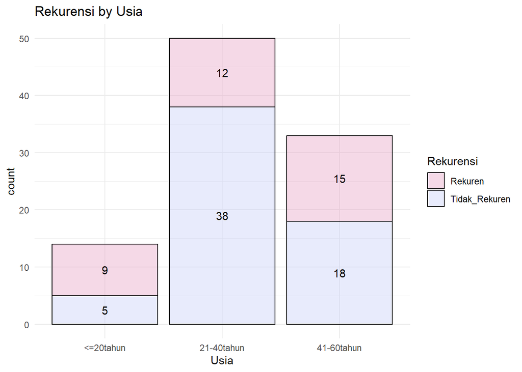

```r
ggplot(dataku, aes(x=Usia, fill=Rekurensi)) +
  geom_bar(colour = "black", alpha = 0.4) +
  ggtitle("Rekurensi by Usia", ) +
  theme(plot.title = element_text(hjust = 0.4)) +
  geom_text(stat = "count", aes(label =..count..), position=position_stack(vjust=0.5)) +
  scale_fill_manual(values = wes_palette("GrandBudapest2")) + theme_minimal()
```

```r
#Rekurensi-Jenis Kelamin
table(dataku$JK, dataku$Rekurensi)
```

```
##
##             Rekuren Tidak_Rekuren
##   Laki-laki      14            27
##   Perempuan      22            34
```

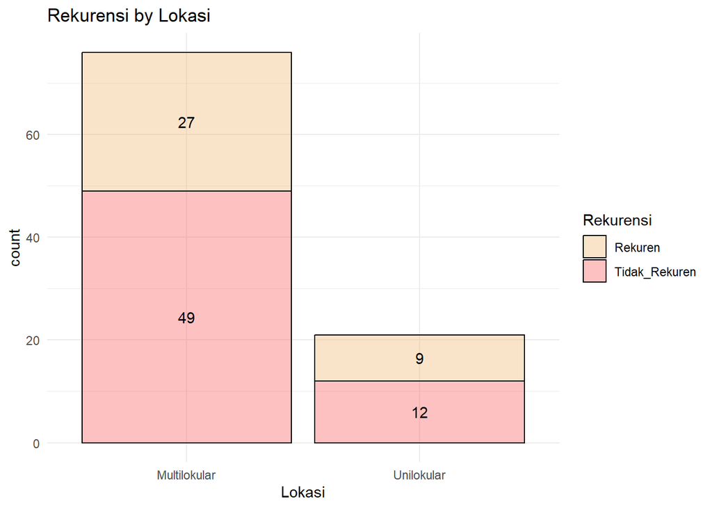

```r
ggplot(dataku, aes(x=Lokasi, fill=Rekurensi)) +
  geom_bar(colour = "black", alpha = 0.4) +
  ggtitle("Rekurensi by Lokasi", ) +
  theme(plot.title = element_text(hjust = 0.4)) +
  geom_text(stat = "count", aes(label =..count..), position=position_stack(vjust=0.5)) +
  scale_fill_manual(values = wes_palette("GrandBudapest1")) + theme_minimal()
```

```r
#Rekurensi-Perluasan
table(dataku$Perluasan, dataku$Rekurensi)
```

```
##
##           Rekuren Tidak_Rekuren
##   Stage_2      16            58
##   Stage_1      20             3
```

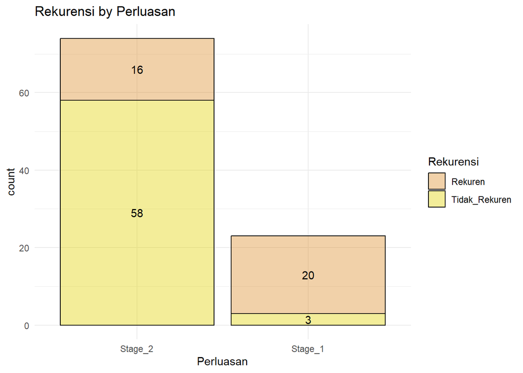

```r
ggplot(dataku, aes(x=Perluasan, fill=Rekurensi)) +
  geom_bar(colour = "black", alpha = 0.4) +
  ggtitle("Rekurensi by Perluasan", ) +
  theme(plot.title = element_text(hjust = 0.4)) +
  geom_text(stat = "count", aes(label =..count..), position=position_stack(vjust=0.5)) +
  scale_fill_manual(values = wes_palette("FantasticFox1")) + theme_minimal()
```

```r
#Rekurensi-Radiografis
table(dataku$Radiografis, dataku$Rekurensi)
```

```
##
##                Rekuren Tidak_Rekuren
##   Multilokular      27            49
##   Unilokular         9            12
```

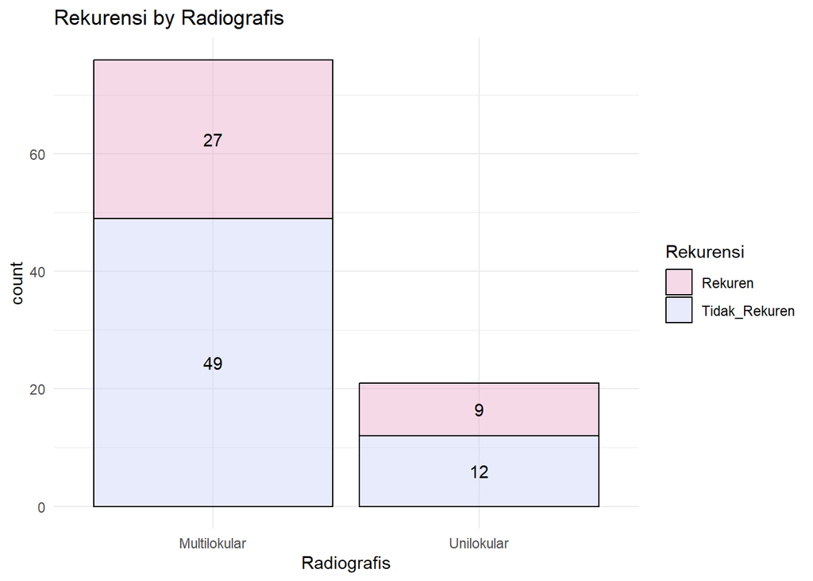

```r
ggplot(dataku, aes(x=Radiografis, fill=Rekurensi)) +
  geom_bar(colour = "black", alpha = 0.4) +
  ggtitle("Rekurensi by Radiografis", ) +
  theme(plot.title = element_text(hjust = 0.4)) +
  geom_text(stat = "count", aes(label =..count..), position=position_stack(vjust=0.5)) +
  scale_fill_manual(values = wes_palette("GrandBudapest2")) + theme_minimal()
```

```r
#Rekurensi-Histopatologis
table(dataku$Histopatologis, dataku$Rekurensi)
```

```
##
##                Rekuren Tidak_Rekuren
##   Folikular          9             4
##   Pleksiform         2             3
##   Akantomatosa       1             0
##   Desmoplastik       1             5
##   Campuran          22            48
##   Unikistik          1             1
```

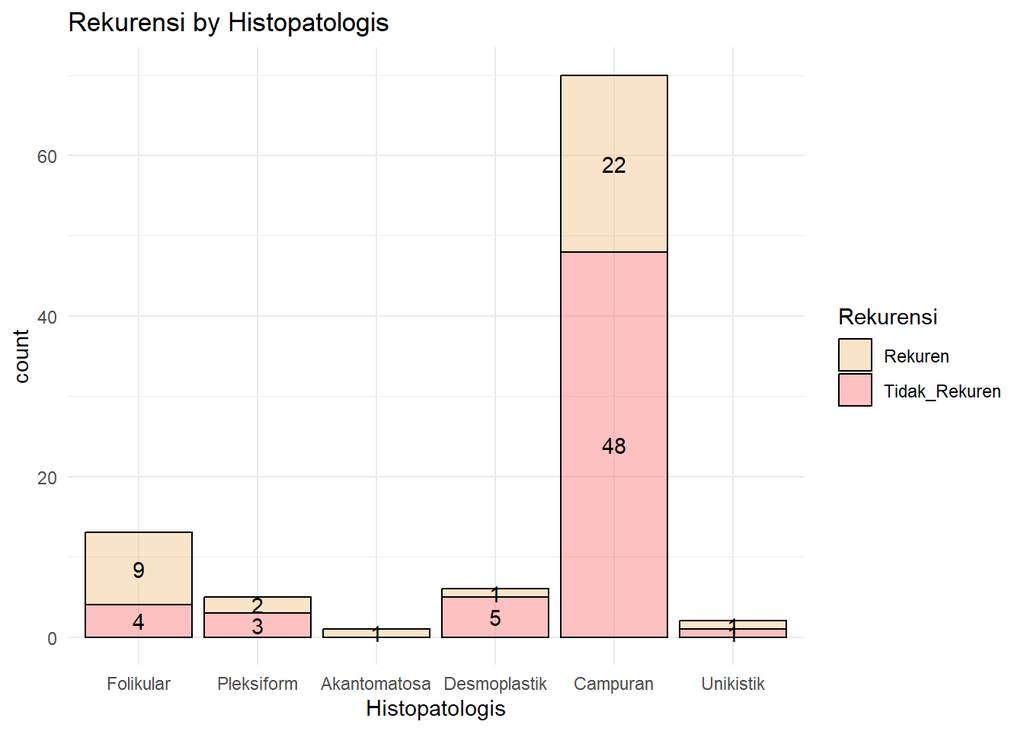

```r
ggplot(dataku, aes(x=Histopatologis, fill=Rekurensi)) +
  geom_bar(colour = "black", alpha = 0.4) +
  ggtitle("Rekurensi by Histopatologis", ) +
  theme(plot.title = element_text(hjust = 0.4)) +
  geom_text(stat = "count", aes(label =..count..), position=position_stack(vjust=0.5)) +
  scale_fill_manual(values = wes_palette("GrandBudapest1")) + theme_minimal()
```

```r
#Rekurensi-Modalitasperawatan
table(dataku$Modalitasperawatan, dataku$Rekurensi)
```

```
##
##               Rekuren Tidak_Rekuren
##   Konservatif      27             1
##   Radikal           9            60
```

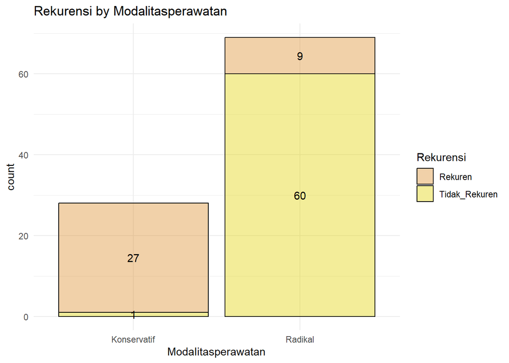

```r
ggplot(dataku, aes(x=Modalitasperawatan, fill=Rekurensi)) +
  geom_bar(colour = "black", alpha = 0.4) +
  ggtitle("Rekurensi by Modalitasperawatan", ) +
  theme(plot.title = element_text(hjust = 0.4)) +
  geom_text(stat = "count", aes(label =..count..), position=position_stack(vjust=0.5)) +
  scale_fill_manual(values = wes_palette("FantasticFox1")) + theme_minimal()
```

## Partisi Data

Partisi data akan menggunakan proporsi 80% untuk *training* dan 20% untuk *testing*. (1)

```r
# set nilai random generator
set.seed(1234)

# membagi data 80% training, 20% testing
bagi <- createDataPartition(dataku$Rekurensi, p = 0.8, list=F)
training<- dataku[bagi,]
testing<- dataku[-bagi,]

# dimensi data training
dim(training)
```

```
## [1] 78  8
```

```r
# summary deskriptif
summary(training)
```

```
##          JK             Usia             Lokasi     Perluasan
##  Laki-laki:31   <=20tahun :11   Multilokular:62   Stage_2:60
##  Perempuan:47   21-40tahun:40   Unilokular  :16   Stage_1:18
##                 41-60tahun:27
##
##
##
##        Radiografis      Histopatologis   Modalitasperawatan         Rekurensi
##  Multilokular:62   Folikular   :11     Konservatif:23       Rekuren      :29
##  Unilokular  :16   Pleksiform  : 5     Radikal    :55       Tidak_Rekuren:49
##                    Akantomatosa: 1
##                    Desmoplastik: 4
##                    Campuran    :57
##                    Unikistik   : 0
```

```r
# Proporsi rekurensi
prop.table(table(training$Rekurensi))
```

```
##
##       Rekuren Tidak_Rekuren
##     0.3717949     0.6282051
```

# Proses Data

## Metode Validasi dengan *K-Fold Cross-Validation* 5 Lipat

Umumnya, *cross-validation* yang digunakan adalah 10 kali lipat, namun karena sampel kecil, pada uji ini dilakukan 5 kali lipatan.(2)

```r
control <- trainControl(method = "cv", number = 5, classProbs = TRUE)
```

## Regresi Logistik

```r
modelrl<-train(Rekurensi~., data=training,
               method="glm", trControl=control)
# summary
modelrl
```

```
## Generalized Linear Model
##
## 78 samples
##  7 predictor
##  2 classes: 'Rekuren', 'Tidak_Rekuren'
##
## No pre-processing
## Resampling: Cross-Validated (5 fold)
## Summary of sample sizes: 62, 63, 63, 62, 62
## Resampling results:
##
##   Accuracy  Kappa
##   0.8225    0.6073753
```

```r
summary(modelrl)
```

```
##
## Call:
## NULL
##
## Coefficients: (2 not defined because of singularities)
##                              Estimate Std. Error z value Pr(>|z|)
## (Intercept)                -4.500e+00  1.939e+00  -2.321 0.020273 *
## JKPerempuan                 1.338e+00  9.993e-01   1.339 0.180636
## `Usia21-40tahun`           -4.417e-01  1.632e+00  -0.271 0.786725
## `Usia41-60tahun`           -5.738e-01  1.789e+00  -0.321 0.748439
## LokasiUnilokular            1.141e+00  1.498e+00   0.761 0.446434
## PerluasanStage_1           -2.007e+00  1.587e+00  -1.265 0.206009
## RadiografisUnilokular              NA         NA      NA       NA
## HistopatologisPleksiform    2.484e+00  2.515e+00   0.988 0.323254
## HistopatologisAkantomatosa -1.397e+01  2.400e+03  -0.006 0.995355
## HistopatologisDesmoplastik  5.253e-04  1.639e+00   0.000 0.999744
## HistopatologisCampuran      1.648e+00  1.213e+00   1.359 0.174235
## HistopatologisUnikistik            NA         NA      NA       NA
## ModalitasperawatanRadikal   5.031e+00  1.481e+00   3.398 0.000679 ***
## ---
## Signif. codes:  0 '***' 0.001 '**' 0.01 '*' 0.05 '.' 0.1 ' ' 1
##
## (Dispersion parameter for binomial family taken to be 1)
##
##     Null deviance: 102.945  on 77  degrees of freedom
## Residual deviance:  42.525  on 67  degrees of freedom
## AIC: 64.525
##
## Number of Fisher Scoring iterations: 15
```

```r
# akurasi setiap fold
modelrl$resample
```

```
##    Accuracy     Kappa Resample
## 1 0.8750000 0.7333333    Fold1
## 2 0.8666667 0.7058824    Fold2
## 3 0.9333333 0.8421053    Fold3
## 4 0.8125000 0.5555556    Fold4
## 5 0.6250000 0.2000000    Fold5
```

```r
# final model
modelrl$finalModel
```

```
##
## Call:  NULL
##
## Coefficients:
##                (Intercept)                 JKPerempuan
##                 -4.500e+00                   1.338e+00
##           `Usia21-40tahun`            `Usia41-60tahun`
##                 -4.417e-01                  -5.738e-01
##           LokasiUnilokular            PerluasanStage_1
##                  1.141e+00                  -2.007e+00
##      RadiografisUnilokular    HistopatologisPleksiform
##                         NA                   2.484e+00
## HistopatologisAkantomatosa  HistopatologisDesmoplastik
##                 -1.397e+01                   5.253e-04
##     HistopatologisCampuran     HistopatologisUnikistik
##                  1.648e+00                          NA
##  ModalitasperawatanRadikal
##                  5.031e+00
##
## Degrees of Freedom: 77 Total (i.e. Null);  67 Residual
## Null Deviance:       102.9
## Residual Deviance: 42.52     AIC: 64.52
```

```r
# prediksi
testing$predrl <- predict(modelrl, newdata=testing)
DT::datatable(head(testing))
```

|  | JK | Usia | Lokasi | Perluasan | Radiografis | Histopatologis | Modalitasperawatan | Rekurensi | predrl |
| --- | --- | --- | --- | --- | --- | --- | --- | --- | --- |
| 1 | Perempuan | 41-60tahun | Multilokular | Stage_1 | Multilokular | Campuran | Konservatif | Rekuren | Rekuren |
| 2 | Perempuan | 21-40tahun | Multilokular | Stage_2 | Multilokular | Campuran | Radikal | Rekuren | Tidak_Rekuren |
| 3 | Laki-laki | 41-60tahun | Multilokular | Stage_2 | Multilokular | Campuran | Radikal | Rekuren | Tidak_Rekuren |
| 4 | Perempuan | 21-40tahun | Multilokular | Stage_1 | Multilokular | Folikular | Konservatif | Rekuren | Rekuren |
| 5 | Perempuan | 21-40tahun | Multilokular | Stage_2 | Multilokular | Campuran | Radikal | Tidak_Rekuren | Tidak_Rekuren |
| 6 | Laki-laki | 21-40tahun | Unilokular | Stage_2 | Unilokular | Unikistik | Radikal | Tidak_Rekuren | Tidak_Rekuren |

```r
# akurasi model
confusionMatrix(testing$predrl, testing$Rekurensi, positive="Rekuren")
```

```
## Confusion Matrix and Statistics
##
##                Reference
## Prediction      Rekuren Tidak_Rekuren
##   Rekuren             5             2
##   Tidak_Rekuren       2            10
##
##                Accuracy : 0.7895
##                  95% CI : (0.5443, 0.9395)
##     No Information Rate : 0.6316
##     P-Value [Acc > NIR] : 0.1149
##
##                   Kappa : 0.5476
##
##  Mcnemar's Test P-Value : 1.0000
##
##             Sensitivity : 0.7143
##             Specificity : 0.8333
##          Pos Pred Value : 0.7143
##          Neg Pred Value : 0.8333
##              Prevalence : 0.3684
##          Detection Rate : 0.2632
##    Detection Prevalence : 0.3684
##       Balanced Accuracy : 0.7738
##
##        'Positive' Class : Rekuren
##
```

```r
# melihat variabel importance
varImp(modelrl)
```

```
## glm variable importance
##
##                             Overall
## ModalitasperawatanRadikal  100.0000
## HistopatologisCampuran      39.9829
## JKPerempuan                 39.3965
## PerluasanStage_1            37.2131
## HistopatologisPleksiform    29.0651
## LokasiUnilokular            22.4007
## `Usia41-60tahun`             9.4300
## `Usia21-40tahun`             7.9544
## HistopatologisAkantomatosa   0.1619
## HistopatologisDesmoplastik   0.0000
```

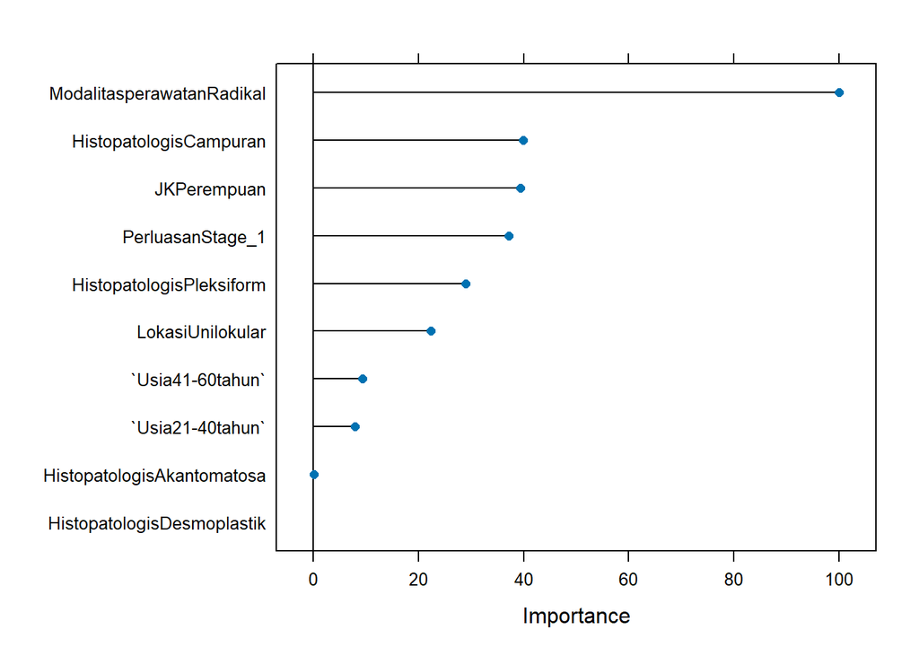

```r
importance <- varImp(modelrl)
plot(importance)
```

## Deicision Tree

Pada hasil uji *decision tree* didapatkan Modalitasperawatan yang Radikal satu-satunya variabel yang dapat masuk dalam uji ini. Didapatkan bahwa 96 persen dari rekuren sesuai dengan asumsi *training*, sedangkan pada tidak rekuren didapatkan ketepatan sebesar 87 persen. Modalitasperawatan yang Radikal menjadi variabel terpenting dalam uji ini.

```r
modeldt<-train(Rekurensi~., data=training,
               method="rpart", trControl=control, tuneLength = 5)
# summary
modeldt
```

```
## CART
##
## 78 samples
##  7 predictor
##  2 classes: 'Rekuren', 'Tidak_Rekuren'
##
## No pre-processing
## Resampling: Cross-Validated (5 fold)
## Summary of sample sizes: 62, 62, 64, 62, 62
## Resampling results across tuning parameters:
##
##   cp         Accuracy   Kappa
##   0.0000000  0.8982143  0.77039753
##   0.1810345  0.8982143  0.77039753
##   0.3620690  0.8982143  0.77039753
##   0.5431034  0.8982143  0.77039753
##   0.7241379  0.6535714  0.08571429
##
## Accuracy was used to select the optimal model using the largest value.
## The final value used for the model was cp = 0.5431034.
```

```r
# akurasi setiap fold
modeldt$resample
```

```
##    Accuracy     Kappa Resample
## 1 0.7500000 0.4285714    Fold1
## 2 0.9285714 0.8372093    Fold3
## 3 0.9375000 0.8620690    Fold4
## 4 0.9375000 0.8620690    Fold5
## 5 0.9375000 0.8620690    Fold2
```

```r
# final model
modeldt$finalModel
```

```
## n= 78
##
## node), split, n, loss, yval, (yprob)
##       * denotes terminal node
##
## 1) root 78 29 Tidak_Rekuren (0.37179487 0.62820513)
##   2) ModalitasperawatanRadikal< 0.5 23  1 Rekuren (0.95652174 0.04347826) *
##   3) ModalitasperawatanRadikal>=0.5 55  7 Tidak_Rekuren (0.12727273 0.87272727) *
```

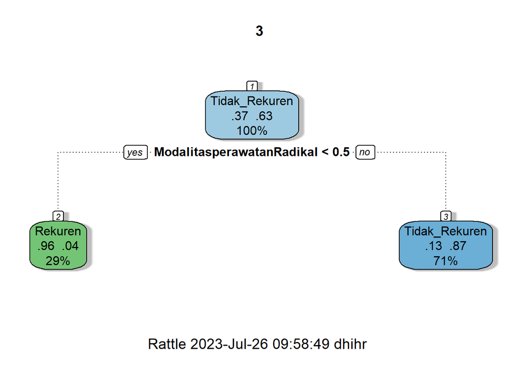

```r
# menampilkan plot decision tree
library(rattle)
fancyRpartPlot(modeldt$finalModel, 3)
```

```r
# prediksi
testing$preddt <- predict(modeldt, newdata=testing)
DT::datatable(head(testing))
```

|  | JK | Usia | Lokasi | Perluasan | Radiografis | Histopatologis | Modalitasperawatan | Rekurensi | predrl | preddt |
| --- | --- | --- | --- | --- | --- | --- | --- | --- | --- | --- |
| 1 | Perempuan | 41-60tahun | Multilokular | Stage_1 | Multilokular | Campuran | Konservatif | Rekuren | Rekuren | Rekuren |
| 2 | Perempuan | 21-40tahun | Multilokular | Stage_2 | Multilokular | Campuran | Radikal | Rekuren | Tidak_Rekuren | Tidak_Rekuren |
| 3 | Laki-laki | 41-60tahun | Multilokular | Stage_2 | Multilokular | Campuran | Radikal | Rekuren | Tidak_Rekuren | Tidak_Rekuren |
| 4 | Perempuan | 21-40tahun | Multilokular | Stage_1 | Multilokular | Folikular | Konservatif | Rekuren | Rekuren | Rekuren |
| 5 | Perempuan | 21-40tahun | Multilokular | Stage_2 | Multilokular | Campuran | Radikal | Tidak_Rekuren | Tidak_Rekuren | Tidak_Rekuren |
| 6 | Laki-laki | 21-40tahun | Unilokular | Stage_2 | Unilokular | Unikistik | Radikal | Tidak_Rekuren | Tidak_Rekuren | Tidak_Rekuren |

```r
# akurasi model
confusionMatrix(testing$preddt, testing$Rekurensi, positive="Rekuren")
```

```
## Confusion Matrix and Statistics
##
##                Reference
## Prediction      Rekuren Tidak_Rekuren
##   Rekuren             5             0
##   Tidak_Rekuren       2            12
##
##                Accuracy : 0.8947
##                  95% CI : (0.6686, 0.987)
##     No Information Rate : 0.6316
##     P-Value [Acc > NIR] : 0.01135
##
##                   Kappa : 0.7595
##
##  Mcnemar's Test P-Value : 0.47950
##
##             Sensitivity : 0.7143
##             Specificity : 1.0000
##          Pos Pred Value : 1.0000
##          Neg Pred Value : 0.8571
##              Prevalence : 0.3684
##          Detection Rate : 0.2632
##    Detection Prevalence : 0.2632
##       Balanced Accuracy : 0.8571
##
##        'Positive' Class : Rekuren
##
```

```r
# melihat variabel importance
varImp(modeldt)
```

```
## rpart variable importance
##
##                            Overall
## ModalitasperawatanRadikal  100.000
## PerluasanStage_1            56.103
## Usia21-40tahun              10.921
## HistopatologisCampuran      10.269
## Usia41-60tahun               1.954
## HistopatologisAkantomatosa   0.000
## LokasiUnilokular             0.000
## HistopatologisUnikistik      0.000
## `Usia41-60tahun`             0.000
## HistopatologisDesmoplastik   0.000
## JKPerempuan                  0.000
## `Usia21-40tahun`             0.000
## RadiografisUnilokular        0.000
## HistopatologisPleksiform     0.000
```

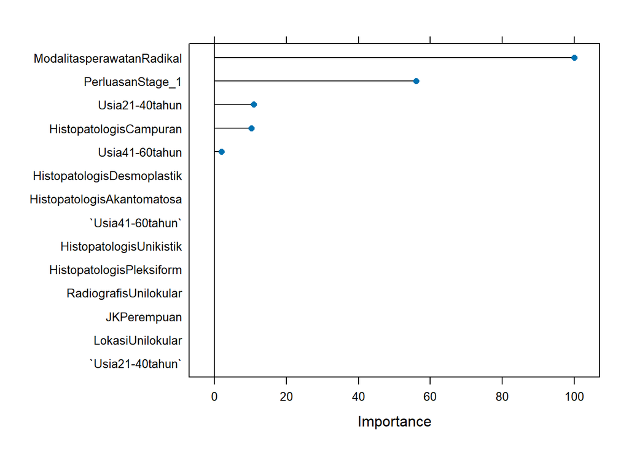

```r
importance <- varImp(modeldt)
plot(importance)
```

## Random Forest

```r
modelrf<-train(Rekurensi~., data=training,
               method="rf", trControl=control, tuneLength = 100)
# summary
modelrf
```

```
## Random Forest
##
## 78 samples
##  7 predictor
##  2 classes: 'Rekuren', 'Tidak_Rekuren'
##
## No pre-processing
## Resampling: Cross-Validated (5 fold)
## Summary of sample sizes: 63, 62, 62, 62, 63
## Resampling results across tuning parameters:
##
##   mtry  Accuracy   Kappa
##    2    0.8725000  0.7163627
##    3    0.8858333  0.7466148
##    4    0.8858333  0.7466148
##    5    0.8858333  0.7466148
##    6    0.8733333  0.7227068
##    7    0.8733333  0.7227068
##    8    0.8733333  0.7227068
##    9    0.8733333  0.7227068
##   10    0.8600000  0.6924547
##   11    0.8600000  0.6924547
##   12    0.8600000  0.6924547
##
## Accuracy was used to select the optimal model using the largest value.
## The final value used for the model was mtry = 3.
```

```r
# akurasi setiap fold
modelrf$resample
```

```
##    Accuracy     Kappa Resample
## 1 0.9333333 0.8571429    Fold5
## 2 0.8125000 0.5862069    Fold4
## 3 0.8750000 0.7333333    Fold3
## 4 0.8750000 0.7142857    Fold2
## 5 0.9333333 0.8421053    Fold1
```

```r
# final model
modelrf$finalModel
```

```
##
## Call:
##  randomForest(x = x, y = y, mtry = param$mtry)
##                Type of random forest: classification
##                      Number of trees: 500
## No. of variables tried at each split: 3
##
##         OOB estimate of  error rate: 11.54%
## Confusion matrix:
##               Rekuren Tidak_Rekuren class.error
## Rekuren            22             7  0.24137931
## Tidak_Rekuren       2            47  0.04081633
```

```r
# prediksi
testing$predrf <- predict(modelrf, newdata=testing)
DT::datatable(head(testing))
```

|  | JK | Usia | Lokasi | Perluasan | Radiografis | Histopatologis | Modalitasperawatan | Rekurensi | predrl | preddt | predrf |
| --- | --- | --- | --- | --- | --- | --- | --- | --- | --- | --- | --- |
| 1 | Perempuan | 41-60tahun | Multilokular | Stage_1 | Multilokular | Campuran | Konservatif | Rekuren | Rekuren | Rekuren | Rekuren |
| 2 | Perempuan | 21-40tahun | Multilokular | Stage_2 | Multilokular | Campuran | Radikal | Rekuren | Tidak_Rekuren | Tidak_Rekuren | Tidak_Rekuren |
| 3 | Laki-laki | 41-60tahun | Multilokular | Stage_2 | Multilokular | Campuran | Radikal | Rekuren | Tidak_Rekuren | Tidak_Rekuren | Tidak_Rekuren |
| 4 | Perempuan | 21-40tahun | Multilokular | Stage_1 | Multilokular | Folikular | Konservatif | Rekuren | Rekuren | Rekuren | Rekuren |
| 5 | Perempuan | 21-40tahun | Multilokular | Stage_2 | Multilokular | Campuran | Radikal | Tidak_Rekuren | Tidak_Rekuren | Tidak_Rekuren | Tidak_Rekuren |
| 6 | Laki-laki | 21-40tahun | Unilokular | Stage_2 | Unilokular | Unikistik | Radikal | Tidak_Rekuren | Tidak_Rekuren | Tidak_Rekuren | Tidak_Rekuren |

```r
# akurasi model
confusionMatrix(testing$predrf, testing$Rekurensi, positive="Rekuren")
```

```
## Confusion Matrix and Statistics
##
##                Reference
## Prediction      Rekuren Tidak_Rekuren
##   Rekuren             5             1
##   Tidak_Rekuren       2            11
##
##                Accuracy : 0.8421
##                  95% CI : (0.6042, 0.9662)
##     No Information Rate : 0.6316
##     P-Value [Acc > NIR] : 0.04241
##
##                   Kappa : 0.6503
##
##  Mcnemar's Test P-Value : 1.00000
##
##             Sensitivity : 0.7143
##             Specificity : 0.9167
##          Pos Pred Value : 0.8333
##          Neg Pred Value : 0.8462
##              Prevalence : 0.3684
##          Detection Rate : 0.2632
##    Detection Prevalence : 0.3158
##       Balanced Accuracy : 0.8155
##
##        'Positive' Class : Rekuren
##
```

```r
# melihat variabel importance
varImp(modelrf)
```

```
## rf variable importance
##
##                            Overall
## ModalitasperawatanRadikal  100.000
## PerluasanStage_1            45.806
## HistopatologisCampuran      13.866
## Usia21-40tahun               9.634
## Usia41-60tahun               6.447
## HistopatologisDesmoplastik   5.656
## JKPerempuan                  5.625
## LokasiUnilokular             4.839
## RadiografisUnilokular        4.831
## HistopatologisPleksiform     2.604
## HistopatologisAkantomatosa   1.630
## HistopatologisUnikistik      0.000
```

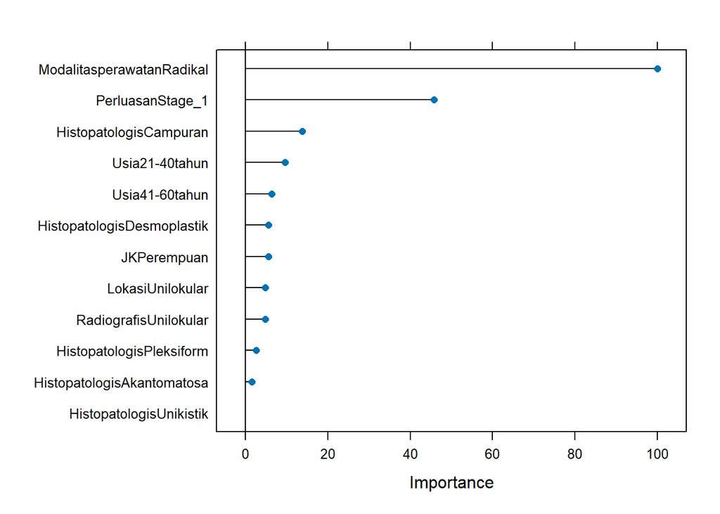

```r
importance <- varImp(modelrf)
plot(importance)
```

# Komparasi Model

## Mengecek Akurasi Masing-Masing Model

Kesemua model di sini memiliki akurasi yang cukup tinggi (>70 persen), namun perlu diingat bahwa sampel dalam uji ini jumlahnya kecil (97 sampel), dengan *testing* sebesar 19 sampel. Sehingga sebaiknya dilakukan peningkatan dalam jumlah sampel.

```r
model_list <- list(LogisticRegression = modelrl,
                   DecisionTree = modeldt,
                   RandomForest = modelrf)
res <- resamples(model_list)
summary(res)
```

```
##
## Call:
## summary.resamples(object = res)
##
## Models: LogisticRegression, DecisionTree, RandomForest
## Number of resamples: 5
##
## Accuracy
##                      Min.   1st Qu.    Median      Mean   3rd Qu.      Max.
## LogisticRegression 0.6250 0.8125000 0.8666667 0.8225000 0.8750000 0.9333333
## DecisionTree       0.7500 0.9285714 0.9375000 0.8982143 0.9375000 0.9375000
## RandomForest       0.8125 0.8750000 0.8750000 0.8858333 0.9333333 0.9333333
##                    NA's
## LogisticRegression    0
## DecisionTree          0
## RandomForest          0
##
## Kappa
##                         Min.   1st Qu.    Median      Mean   3rd Qu.      Max.
## LogisticRegression 0.2000000 0.5555556 0.7058824 0.6073753 0.7333333 0.8421053
## DecisionTree       0.4285714 0.8372093 0.8620690 0.7703975 0.8620690 0.8620690
## RandomForest       0.5862069 0.7142857 0.7333333 0.7466148 0.8421053 0.8571429
##                    NA's
## LogisticRegression    0
## DecisionTree          0
## RandomForest          0
```

## Melihat Perbadingan di *Forest Plot*

Di sini bisa dilihat bahwa *decision tree* adalah metode terbaik dalam melakukan prediksi pada data di studi ini, dengan menggunakan median sebagai nilai tengah.

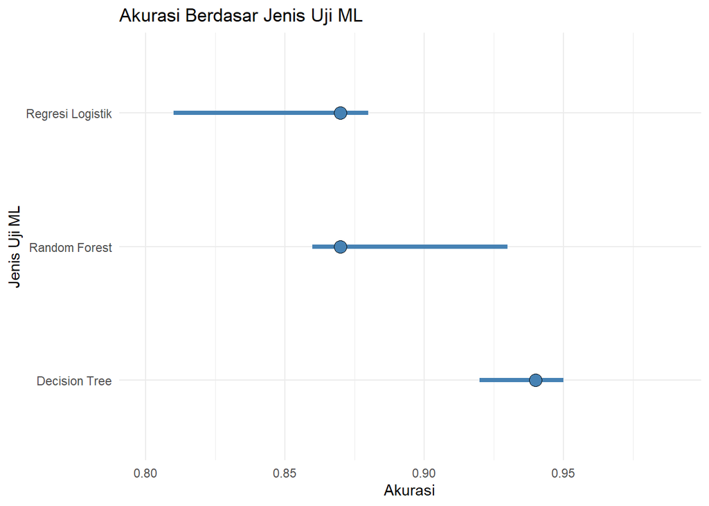

```r
sample_data <- data.frame(study=c('Regresi Logistik', 'Decision Tree', 'Random Forest'),
                          index=1:3,
                          median=c(0.87, 0.94, 0.87),
                          error_lower=c(0.81, 0.92, 0.86),
                          error_upper=c(0.88, 0.95, 0.93))
ggplot(sample_data, aes(x=study, y=median, ymin=error_lower, ymax=error_upper)) +
  geom_linerange(size=1.5,position=position_dodge(width = 0.5), color = 'steelblue') +
  geom_point(size=4, shape=21, fill="steelblue", stroke = 0.5,position=position_dodge(width = 0.5)) +
  ggtitle("Akurasi Berdasar Jenis Uji ML", ) +
  scale_x_discrete(name="Jenis Uji ML") +
  scale_y_continuous(name="Akurasi", limits = c(0.8,0.99 )) +
  coord_flip() +
  theme_minimal()
```

# Daftar Pustaka

1. Korjus K, Hebart MN, Vicente R. An Efficient Data Partitioning to Improve Classification Performance While Keeping Parameters Interpretable. PLoS One. 2016;11(8):e0161788. Published 2016 Aug 26. doi:10.1371/journal.pone.0161788
2. Browniee J, How to Configure k-Fold Cross-Validation, https://machinelearningmastery.com/how-to-configure-k-fold-cross-validation/